# DATA 606 Data Project Proposal

Gabriel Campos

### Data Preparation

```r
west <- project_data %>%
  filter(State == "Arizona"| State == "California"| State =="Colorado"| State =="Idaho"| State =="Montana"
       | State =="Nevada"| State == "New Mexico"| State =="Oregon" | State == "Utah"| State =="Washington"
       | State =="Wyoming")
midwest <- project_data %>%
  filter(State == "Illinois"| State == "Indiana"| State =="Iowa"| State =="Kansas"| State =="Michigan"
       | State =="Minnesota"| State == "Missouri"| State =="Nebraska" | State == "North Dakota"| State =="Ohio"
       | State =="South Dakota"| State =="Wisconsin")
northeast <- project_data %>%
  filter(State == "Connecticut"| State == "Delaware"| State =="Maine"| State =="Massachusetts"
       | State =="New Hampshire"| State =="New Jersey"| State == "New York"| State =="Pennsylvania"
       | State == "Rhode Island"| State =="Vermont")
south <- project_data %>%
  filter(State == "Alabama"| State == "Arkansas"| State =="Florida"| State =="Georgia"| State =="Kentucky"
       | State =="Louisiana"| State == "Mississippi"| State =="North Carolina"| State == "Oklahoma"
       | State =="South Carolina"| State =="South Carolina"| State =="Tennessee"| State =="Texas"| State =="Virgina"
       | State =="West Virgina")
pacific<- project_data %>%
  filter(State == "Alaska"| State == "Hawaii")
```

### Research question

**Question: Between 1980-2014, was the South the most dangerous region to live in the US?**

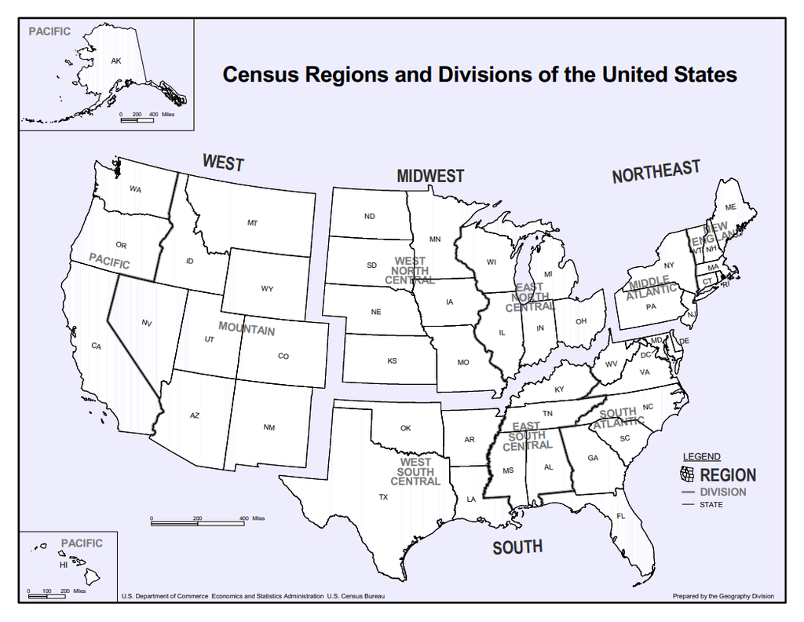

US regions based on [census.gov](https://www2.census.gov/geo/pdfs/maps-data/maps/reference/us_regdiv.pdf)

$H_0$ = $Region_{south}\le Region_{west..midwest...northeast...pacific}$ $H_A$ = $Region_{south}> Region_{west..midwest...northeast...pacific}$

### Data collection

**Describe the method of data collection.**

**Data source: [kaggle.com](https://www.kaggle.com/murderaccountability/homicide-reports?select=database.csv)**

```
Content
The Murder Accountability Project is the most complete database of homicides in the United States currently
available. This dataset includes murders from the FBI's Supplementary Homicide Report from 1976 to the present
and Freedom of Information Act data on more than 22,000 homicides that were not reported to the Justice
Department. This dataset includes the age, race, sex, ethnicity of victims and perpetrators, in addition to the
relationship between the victim and perpetrator and weapon used.

Acknowledgements
The data was compiled and made available by the Murder Accountability Project, founded by Thomas Hargrove.
```

*Homicide Reports, 1980-2014 Project https://www.kaggle.com/murderaccountability/homicide-reports?select=database.csv*

### Type of study

**What type of study is this (observational/experiment)?**  
Observational

### Data Source

**If you collected the data, state self-collected. If not, provide a citation/link.**

*Homicide Reports, 1980-2014 Project https://www.kaggle.com/murderaccountability/homicide-reports?select=database.csv*

### Dependent Variable

```
##  [1] "Record ID"             "Agency Code"           "Agency Name"
##  [4] "Agency Type"           "City"                  "State"
##  [7] "Year"                  "Month"                 "Incident"
## [10] "Crime Type"            "Crime Solved"          "Victim Sex"
## [13] "Victim Age"            "Victim Race"           "Victim Ethnicity"
## [16] "Perpetrator Sex"       "Perpetrator Age"       "Perpetrator Race"
## [19] "Perpetrator Ethnicity" "Relationship"          "Weapon"
## [22] "Victim Count"          "Perpetrator Count"     "Record Source"
```

**What is the response variable? Is it quantitative or qualitative?**

Region of Murder count, which is counted with Record ID and is quantitative.

### Independent Variable

**You should have two independent variables, one quantitative and one qualitative.** Victim Age (Quantitative) and Victim Sex (Qualitative)

### Relevant summary statistics

**Provide summary statistics for each the variables. Also include appropriate visualizations related to your research question (e.g. scatter plot, boxplots, etc). This step requires the use of R, hence a code chunk is provided below. Insert more code chunks as needed.**

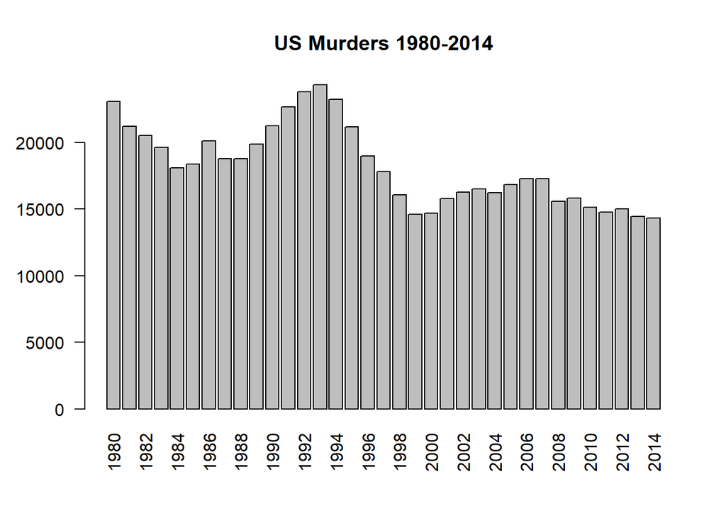

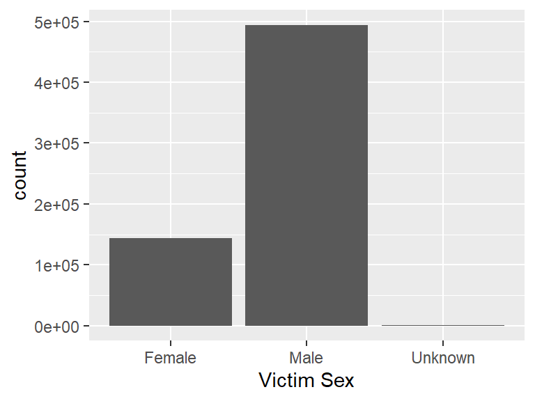

```r
count<-project_data$`Victim Age`
table(count)
```

```
## count
##     0     1     2     3     4     5     6     7     8     9    10    11    12
##  8444  5525  3805  2378  1659  1194   999   915   852   834   854   911  1239
##    13    14    15    16    17    18    19    20    21    22    23    24    25
##  1897  3342  5905  9402 14030 18469 21939 23031 22796 23049 22438 21830 22939
##    26    27    28    29    30    31    32    33    34    35    36    37    38
## 20469 19465 18199 18037 18966 15762 15812 14463 14296 14314 12502 11829 11411
##    39    40    41    42    43    44    45    46    47    48    49    50    51
## 10921 11163  9594  9613  8629  7921  8157  7336  6902  6365  6149  6325  5270
##    52    53    54    55    56    57    58    59    60    61    62    63    64
##  5203  4788  4466  4246  3939  3721  3272  3184  3171  2797  2862  2519  2271
##    65    66    67    68    69    70    71    72    73    74    75    76    77
##  2418  1861  2013  1840  1663  1783  1566  1596  1390  1367  1411  1213  1135
##    78    79    80    81    82    83    84    85    86    87    88    89    90
##  1102  1098  1067   930   835   765   686   627   574   460   408   313   281
##    91    92    93    94    95    96    97    98    99   998
##   215   156   134   116    82    37    39    33  9281   974
```

```r
labs <- c(paste(seq(0, 100, by = 10), seq(0 + 10 - 1, 100 - 1, by = 10),
                sep = "-"), paste(100, "+", sep = ""),"990-100")

labs
```

```
##  [1] "0-9"     "10-19"   "20-29"   "30-39"   "40-49"   "50-59"   "60-69"
##  [8] "70-79"   "80-89"   "90-99"   "100-9"   "100+"    "990-100"
```

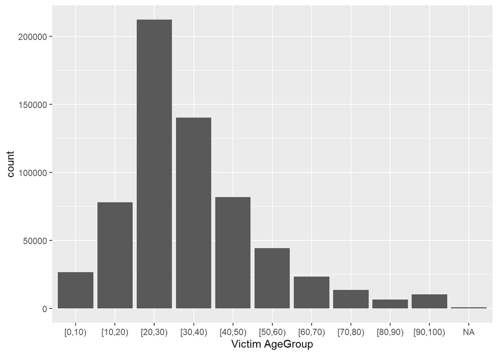

```r
project_data$`Victim AgeGroup`<- cut(project_data$`Victim Age`, breaks=c(0, 10, 20, 30, 40, 50, 60, 70, 80, 90, 100), right = FALSE)
ggplot(project_data)+geom_bar(aes(x=`Victim AgeGroup`))
```